# Bigmart sale prediction

```python
# Importing Libraries

import pandas as pd
import numpy as np
import matplotlib.pyplot as plt
import seaborn as sns
from scipy import stats

#for Spliting Data and Hyperparameter Tuning
from sklearn.model_selection import train_test_split,GridSearchCV

#Importing Machine Learning Model
from catboost import CatBoostRegressor
from sklearn import ensemble
from sklearn.linear_model import LinearRegression
from xgboost import XGBRFRegressor
from sklearn.tree import DecisionTreeRegressor
from sklearn.neighbors import KNeighborsRegressor
from sklearn.neural_network import MLPRegressor
from sklearn.svm import SVR
from lightgbm import LGBMRegressor

#statistical Tools
from sklearn import metrics

#To tranform data
from sklearn import preprocessing

#Setting Format
pd.options.display.float_format = '{:.5f}'.format
pd.options.display.max_columns = None
pd.options.display.max_rows = None
np.random.seed(100)
```

```python
# Importing Data

train = pd.read_csv("D:\\Python Project\\level1\\bigmart\\Train.csv")
test = pd.read_csv("D:\\Python Project\\level1\\bigmart\\Test.csv")
```

```python
data = pd.concat([train,test],ignore_index=True)
data.shape
```

```
(14204, 12)
```

```python
print(train.shape,test.shape)
print(train.shape[0]+test.shape[0])
```

```
(8523, 12) (5681, 11)
14204
```

```python
data.tail(10)
```

|  | Item_Identifier | Item_Weight | Item_Fat_Content | Item_Visibility | Item_Type | Item_MRP | Outlet_Identifier | Outlet_Establishment_Year | Outlet_Size | Outlet_Location_Type | Outlet_Type | Item_Outlet_Sales |
| --- | --- | --- | --- | --- | --- | --- | --- | --- | --- | --- | --- | --- |
| 14194 | FDA01 | 15.00000 | reg | 0.05446 | Canned | 59.59040 | OUT049 | 1999 | Medium | Tier 1 | Supermarket Type1 | nan |
| 14195 | NCH42 | 6.86000 | Low Fat | 0.03659 | Household | 231.10100 | OUT049 | 1999 | Medium | Tier 1 | Supermarket Type1 | nan |
| 14196 | FDF46 | 7.07000 | Low Fat | 0.09405 | Snack Foods | 116.08340 | OUT018 | 2009 | Medium | Tier 3 | Supermarket Type2 | nan |
| 14197 | DRL35 | 15.70000 | Low Fat | 0.03070 | Hard Drinks | 43.27700 | OUT046 | 1997 | Small | Tier 1 | Supermarket Type1 | nan |
| 14198 | FDW46 | 13.00000 | Regular | 0.07041 | Snack Foods | 63.44840 | OUT049 | 1999 | Medium | Tier 1 | Supermarket Type1 | nan |
| 14199 | FDB58 | 10.50000 | Regular | 0.01350 | Snack Foods | 141.31540 | OUT046 | 1997 | Small | Tier 1 | Supermarket Type1 | nan |
| 14200 | FDD47 | 7.60000 | Regular | 0.14299 | Starchy Foods | 169.14480 | OUT018 | 2009 | Medium | Tier 3 | Supermarket Type2 | nan |
| 14201 | NCO17 | 10.00000 | Low Fat | 0.07353 | Health and Hygiene | 118.74400 | OUT045 | 2002 | NaN | Tier 2 | Supermarket Type1 | nan |
| 14202 | FDJ26 | 15.30000 | Regular | 0.00000 | Canned | 214.62180 | OUT017 | 2007 | NaN | Tier 2 | Supermarket Type1 | nan |
| 14203 | FDU37 | 9.50000 | Regular | 0.10472 | Canned | 79.79600 | OUT045 | 2002 | NaN | Tier 2 | Supermarket Type1 | nan |

### Explorative Data Analysis

```python
data.info()
```

```
<class 'pandas.core.frame.DataFrame'>
RangeIndex: 14204 entries, 0 to 14203
Data columns (total 12 columns):
 #   Column                     Non-Null Count  Dtype
---  ------                     --------------  -----
 0   Item_Identifier            14204 non-null  object
 1   Item_Weight                11765 non-null  float64
 2   Item_Fat_Content           14204 non-null  object
 3   Item_Visibility            14204 non-null  float64
 4   Item_Type                  14204 non-null  object
 5   Item_MRP                   14204 non-null  float64
 6   Outlet_Identifier          14204 non-null  object
 7   Outlet_Establishment_Year  14204 non-null  int64
 8   Outlet_Size                10188 non-null  object
 9   Outlet_Location_Type       14204 non-null  object
 10  Outlet_Type                14204 non-null  object
 11  Item_Outlet_Sales          8523 non-null   float64
dtypes: float64(4), int64(1), object(7)
memory usage: 1.3+ MB
```

```python
data.describe(include='all').transpose()
```

|  | count | unique | top | freq | mean | std | min | 25% | 50% | 75% | max |
| --- | --- | --- | --- | --- | --- | --- | --- | --- | --- | --- | --- |
| Item_Identifier | 14204 | 1559 | FDJ20 | 10 | NaN | NaN | NaN | NaN | NaN | NaN | NaN |
| Item_Weight | 11765.00000 | NaN | NaN | NaN | 12.79285 | 4.65250 | 4.55500 | 8.71000 | 12.60000 | 16.75000 | 21.35000 |
| Item_Fat_Content | 14204 | 5 | Low Fat | 8485 | NaN | NaN | NaN | NaN | NaN | NaN | NaN |
| Item_Visibility | 14204.00000 | NaN | NaN | NaN | 0.06595 | 0.05146 | 0.00000 | 0.02704 | 0.05402 | 0.09404 | 0.32839 |
| Item_Type | 14204 | 16 | Fruits and Vegetables | 2013 | NaN | NaN | NaN | NaN | NaN | NaN | NaN |
| Item_MRP | 14204.00000 | NaN | NaN | NaN | 141.00498 | 62.08694 | 31.29000 | 94.01200 | 142.24700 | 185.85560 | 266.88840 |
| Outlet_Identifier | 14204 | 10 | OUT027 | 1559 | NaN | NaN | NaN | NaN | NaN | NaN | NaN |
| Outlet_Establishment_Year | 14204.00000 | NaN | NaN | NaN | 1997.83068 | 8.37166 | 1985.00000 | 1987.00000 | 1999.00000 | 2004.00000 | 2009.00000 |
| Outlet_Size | 10188 | 3 | Medium | 4655 | NaN | NaN | NaN | NaN | NaN | NaN | NaN |
| Outlet_Location_Type | 14204 | 3 | Tier 3 | 5583 | NaN | NaN | NaN | NaN | NaN | NaN | NaN |
| Outlet_Type | 14204 | 4 | Supermarket Type1 | 9294 | NaN | NaN | NaN | NaN | NaN | NaN | NaN |
| Item_Outlet_Sales | 8523.00000 | NaN | NaN | NaN | 2181.28891 | 1706.49962 | 33.29000 | 834.24740 | 1794.33100 | 3101.29640 | 13086.96480 |

Lets Look at all the unique values in Columns

```python
#Extracting the unique values of each columns

for i in data.columns:
    print(i," : distinct_value")
    print(data[i].nunique(), ":No of unique values")
    print(data[i].unique())
    print("-"*30)
    print("")
```

```
Item_Identifier  : distinct_value
1559 :No of unique values
['FDA15' 'DRC01' 'FDN15' ... 'NCF55' 'NCW30' 'NCW05']
------------------------------

Item_Weight  : distinct_value
415 :No of unique values
[ 9.3    5.92  17.5   19.2    8.93  10.395 13.65     nan 16.2   11.8
 18.5   15.1   17.6   16.35   9.    13.35  18.85  14.6   13.85  13.
  7.645 11.65   5.925 19.25  18.6   18.7   17.85  10.     8.85   9.8
 13.6   21.35  12.15   6.42  19.6   15.85   7.39  10.195  9.895 10.895
  7.905  9.195  8.365  7.97  17.7   19.35   8.645 15.6   18.25   7.855
  7.825  8.39  12.85  19.     5.905  7.76  16.75  15.5    6.055  6.305
 20.85  20.75   8.895 19.7    8.75  13.3    8.31  19.75  17.1   10.5
  6.635 14.15   8.89   9.1    7.5   16.85   7.485 11.6   12.65  20.25
  8.6   12.6    8.88  20.5   13.5    7.235  6.92   8.02  12.8   16.6
 14.    16.    21.25   7.365 18.35   5.465  7.27   6.155 19.5   15.2
 14.5   13.1   12.3   11.1   11.3    5.75  11.35   6.525 10.3    5.78
 11.85  18.75   5.26  16.1    9.5   13.8   14.65   6.67   6.11  17.2
  6.32   4.88   5.425 14.1    7.55  17.25  12.    10.1    7.785 13.15
  8.5    7.63   9.285  7.975 15.7    8.985 20.35   6.59  19.85   6.26
 18.2    8.695  7.075  8.195  7.09   6.095  6.15   9.395 15.75   7.475
  6.445 19.1   15.    16.7    7.07   6.48   9.695 11.15   9.6   20.7
  5.5    7.895 17.35   7.285  6.17  11.395  7.71  12.1   14.35   8.1
  8.05  16.5    6.785  7.575  7.47  15.25   7.605 18.    21.2    8.97
 10.6    6.865 10.8   15.15  18.1    6.655 20.1    7.935 15.35  12.35
  6.85   8.775 14.85   7.84  12.5    8.325  5.765  5.985 14.3    6.135
  8.51   6.65   5.695  6.36   8.3    7.56   8.71   6.695 14.8   17.75
  8.575  6.57   8.68   5.63   9.13   6.715  5.82   7.93   5.     7.445
  6.675  8.18   6.98   7.435 20.6    8.355  8.975 20.2    5.655  5.175
 20.     7.67   4.785  8.395  6.175  8.21   5.845  7.17   8.785  7.89
  5.32   5.03   8.945  6.28   7.565  9.31   7.02   5.46   6.13   6.55
 17.    16.25   5.15   7.865  6.575  7.06   5.785  7.42   6.235  6.75
  5.86   5.035  6.38   5.675 11.5   21.    21.1    4.61   7.     6.405
 14.7    7.68   8.185  8.655 10.85   8.42   7.85   4.59   7.51  11.
  6.71  14.75   7.59   5.155  6.365  8.235  5.365  8.485  7.535  4.92
  6.385  8.26   7.945  8.63   9.21   6.965  8.905  7.21   7.3    9.27
 10.695  6.215  7.405  7.72   6.115  6.035  6.78  15.3    7.105  7.52
  4.805  6.425  7.6    6.61   7.325  8.115  5.94   5.635  7.35   5.825
  6.63   7.05   8.315  6.8    7.035  8.96   5.51   8.43   8.27   7.81
```

[output cut: 50 more lines]

```
Outlet_Location_Type  : distinct_value
3 :No of unique values
['Tier 1' 'Tier 3' 'Tier 2']
------------------------------

Outlet_Type  : distinct_value
4 :No of unique values
['Supermarket Type1' 'Supermarket Type2' 'Grocery Store'
 'Supermarket Type3']
------------------------------

Item_Outlet_Sales  : distinct_value
3493 :No of unique values
[3735.138   443.4228 2097.27   ... 3608.636  2778.3834       nan]
------------------------------
```

### Univariate Analysis

```
D:\Users\Sushmita Swain\anaconda3\lib\site-packages\seaborn\_decorators.py:43: FutureWarning: Pass the following variable as a keyword arg: x. From version 0.12, the only valid positional argument will be `data`, and passing other arguments without an explicit keyword will result in an error or misi…
  FutureWarning
```

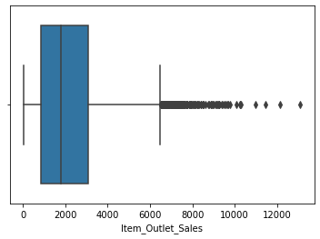

```python
sns.boxplot(train.Item_Outlet_Sales)
```

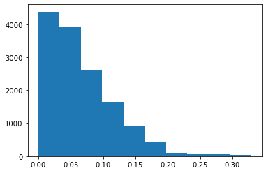

```python
plt.hist(data.Item_Visibility, bins=10)
plt.show()
```

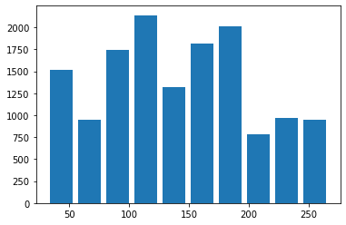

```python
plt.hist(data.Item_MRP, bins=10, rwidth=.8)
plt.show()
```

```
D:\Users\Sushmita Swain\anaconda3\lib\site-packages\seaborn\_decorators.py:43: FutureWarning: Pass the following variable as a keyword arg: x. From version 0.12, the only valid positional argument will be `data`, and passing other arguments without an explicit keyword will result in an error or misi…
  FutureWarning
D:\Users\Sushmita Swain\anaconda3\lib\site-packages\seaborn\_decorators.py:43: FutureWarning: Pass the following variable as a keyword arg: x. From version 0.12, the only valid positional argument will be `data`, and passing other arguments without an explicit keyword will result in an error or misi…
  FutureWarning
D:\Users\Sushmita Swain\anaconda3\lib\site-packages\seaborn\_decorators.py:43: FutureWarning: Pass the following variable as a keyword arg: x. From version 0.12, the only valid positional argument will be `data`, and passing other arguments without an explicit keyword will result in an error or misi…
  FutureWarning
```

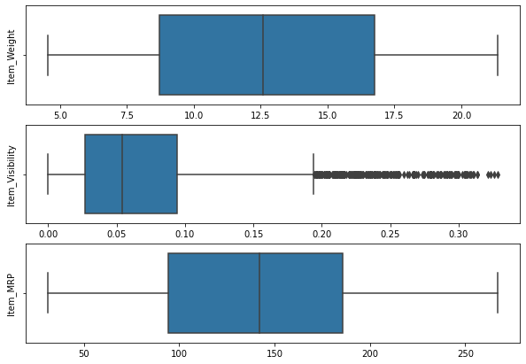

```python
plt.figure(figsize=(10,7))
for i, col in enumerate(['Item_Weight', 'Item_Visibility', 'Item_MRP']):
    plt.subplot(3,1,i+1)
    sns.boxplot(data[col])
    plt.xlabel('')
    plt.ylabel(col)
```

```
D:\Users\Sushmita Swain\anaconda3\lib\site-packages\seaborn\_decorators.py:43: FutureWarning: Pass the following variable as a keyword arg: x. From version 0.12, the only valid positional argument will be `data`, and passing other arguments without an explicit keyword will result in an error or misi…
  FutureWarning
D:\Users\Sushmita Swain\anaconda3\lib\site-packages\seaborn\_decorators.py:43: FutureWarning: Pass the following variable as a keyword arg: x. From version 0.12, the only valid positional argument will be `data`, and passing other arguments without an explicit keyword will result in an error or misi…
  FutureWarning
D:\Users\Sushmita Swain\anaconda3\lib\site-packages\seaborn\_decorators.py:43: FutureWarning: Pass the following variable as a keyword arg: x. From version 0.12, the only valid positional argument will be `data`, and passing other arguments without an explicit keyword will result in an error or misi…
  FutureWarning
```

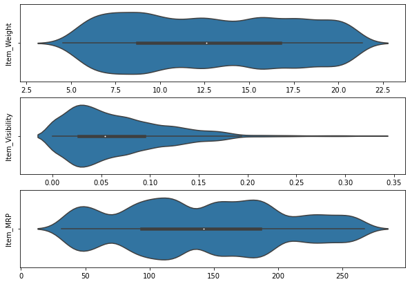

```python
plt.figure(figsize=(10,7))
for i, col in enumerate(['Item_Weight', 'Item_Visibility', 'Item_MRP']):
    plt.subplot(3,1,i+1)
    sns.violinplot(data[col])
    plt.xlabel('')
    plt.ylabel(col)
```

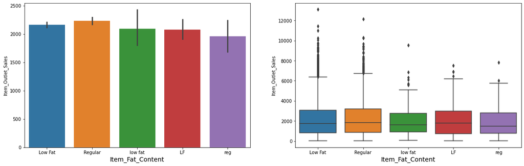

```python
plt.figure(figsize=(20,6))
plt.subplot(1,2,1)
sns.barplot(data=data, y='Item_Outlet_Sales', x='Item_Fat_Content')
plt.xlabel('Item_Fat_Content', fontsize=14)

plt.subplot(1,2,2)
sns.boxplot(data=data, y='Item_Outlet_Sales', x='Item_Fat_Content')
plt.xlabel('Item_Fat_Content', fontsize=14)
plt.show()
```

```
D:\Users\Sushmita Swain\anaconda3\lib\site-packages\seaborn\_decorators.py:43: FutureWarning: Pass the following variable as a keyword arg: x. From version 0.12, the only valid positional argument will be `data`, and passing other arguments without an explicit keyword will result in an error or misi…
  FutureWarning
```

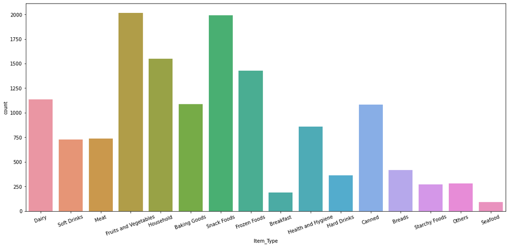

```python
plt.figure(figsize=(18,8))
sns.countplot(data.Item_Type)
plt.xticks(rotation=20)
plt.show()
```

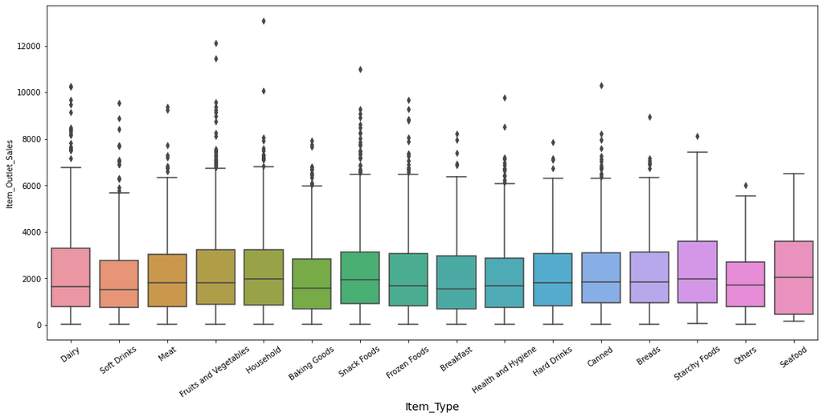

```python
plt.figure(figsize=(18,8))
sns.boxplot(data=data, y='Item_Outlet_Sales', x='Item_Type')
plt.xlabel('Item_Type', fontsize=14)
plt.xticks(rotation=35)
plt.show()
```

```
D:\Users\Sushmita Swain\anaconda3\lib\site-packages\seaborn\_decorators.py:43: FutureWarning: Pass the following variable as a keyword arg: x. From version 0.12, the only valid positional argument will be `data`, and passing other arguments without an explicit keyword will result in an error or misi…
  FutureWarning
```

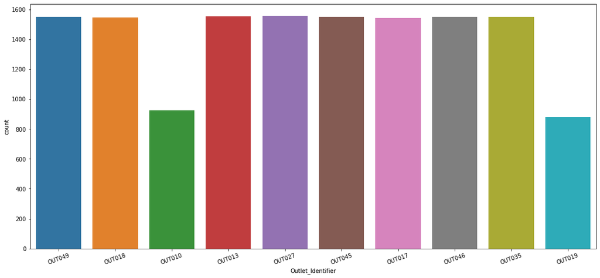

```python
plt.figure(figsize=(18,8))
sns.countplot(data.Outlet_Identifier)
plt.xticks(rotation=20)
plt.show()
```

```
D:\Users\Sushmita Swain\anaconda3\lib\site-packages\seaborn\_decorators.py:43: FutureWarning: Pass the following variable as a keyword arg: x. From version 0.12, the only valid positional argument will be `data`, and passing other arguments without an explicit keyword will result in an error or misi…
  FutureWarning
```

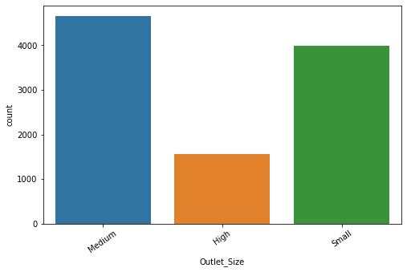

```python
plt.figure(figsize=(8,5))
sns.countplot(data.Outlet_Size)
plt.xticks(rotation=35)
plt.show()
```

```
D:\Users\Sushmita Swain\anaconda3\lib\site-packages\seaborn\_decorators.py:43: FutureWarning: Pass the following variable as a keyword arg: x. From version 0.12, the only valid positional argument will be `data`, and passing other arguments without an explicit keyword will result in an error or misi…
  FutureWarning
```

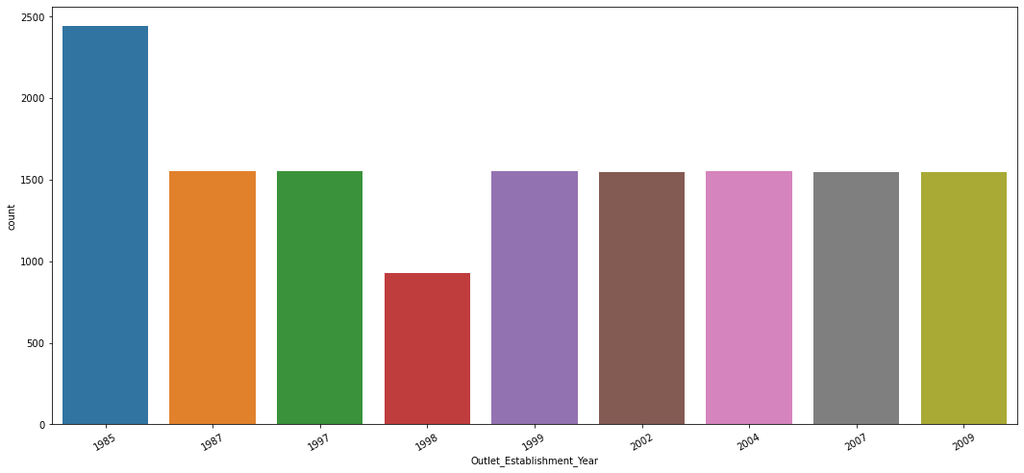

```python
plt.figure(figsize=(18,8))
sns.countplot(data.Outlet_Establishment_Year)
plt.xticks(rotation=30)
plt.show()
```

```
D:\Users\Sushmita Swain\anaconda3\lib\site-packages\seaborn\_decorators.py:43: FutureWarning: Pass the following variable as a keyword arg: x. From version 0.12, the only valid positional argument will be `data`, and passing other arguments without an explicit keyword will result in an error or misi…
  FutureWarning
```

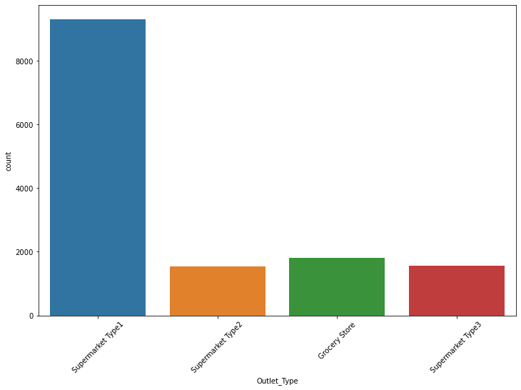

```python
plt.figure(figsize=(12,8))
sns.countplot(data.Outlet_Type)
plt.xticks(rotation=45)
plt.show()
```

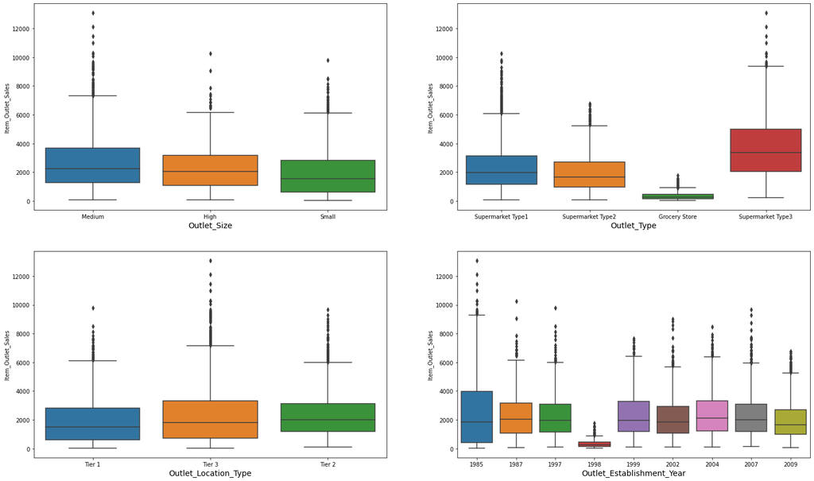

```python
plt.figure(figsize=(25,15))
outlet_col = [ 'Outlet_Size', 'Outlet_Type', 'Outlet_Location_Type','Outlet_Establishment_Year']
for i, col in enumerate(outlet_col):
    plt.subplot(2,2,i+1)
    sns.boxplot(data=data, y='Item_Outlet_Sales', x=col)
    plt.xlabel(col, fontsize=14)
```

#### Multi-variate Analysis

```
D:\Users\Sushmita Swain\anaconda3\lib\site-packages\seaborn\_decorators.py:43: FutureWarning: Pass the following variables as keyword args: x, y. From version 0.12, the only valid positional argument will be `data`, and passing other arguments without an explicit keyword will result in an error or m…
  FutureWarning
```

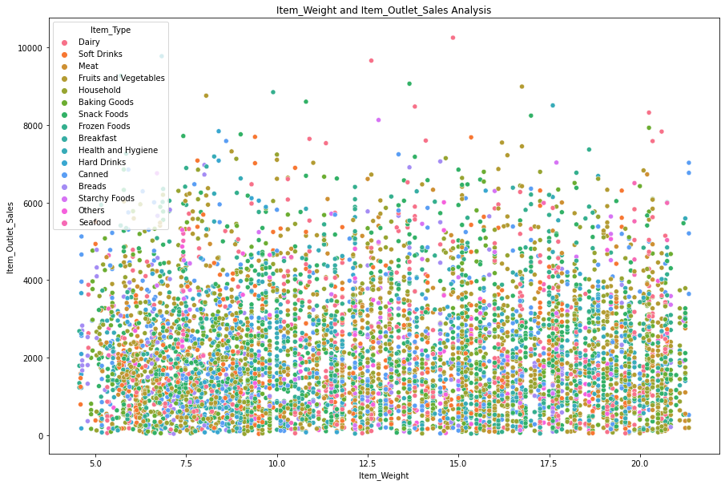

```python
plt.figure(figsize=(15,10))
plt.xlabel("Item_Weight")
plt.ylabel("Item_Outlet_Sales")
plt.title("Item_Weight and Item_Outlet_Sales Analysis")
sns.scatterplot(data.Item_Weight, data.Item_Outlet_Sales, hue=data.Item_Type)
```

```
D:\Users\Sushmita Swain\anaconda3\lib\site-packages\seaborn\_decorators.py:43: FutureWarning: Pass the following variables as keyword args: x, y. From version 0.12, the only valid positional argument will be `data`, and passing other arguments without an explicit keyword will result in an error or m…
  FutureWarning
```

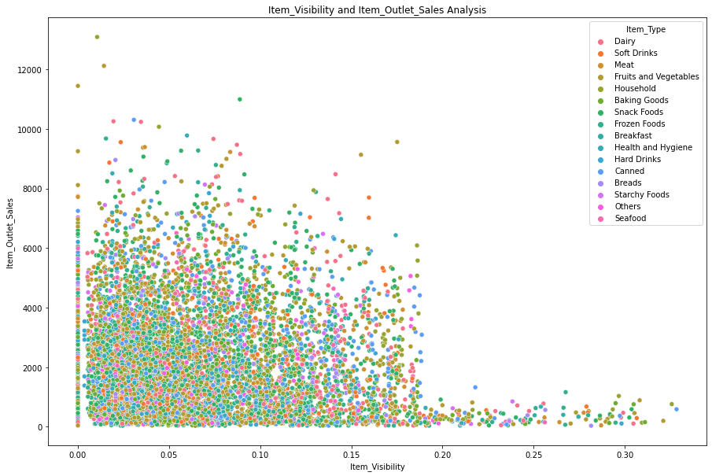

```python
plt.figure(figsize=(15,10))
plt.xlabel("Item_Visibility")
plt.ylabel("Item_Outlet_Sales")
plt.title("Item_Visibility and Item_Outlet_Sales Analysis")
sns.scatterplot(data.Item_Visibility, data.Item_Outlet_Sales, hue=data.Item_Type)
```

### Bivariate Analysis

```
D:\Users\Sushmita Swain\anaconda3\lib\site-packages\seaborn\_decorators.py:43: FutureWarning: Pass the following variables as keyword args: x, y. From version 0.12, the only valid positional argument will be `data`, and passing other arguments without an explicit keyword will result in an error or m…
  FutureWarning
```

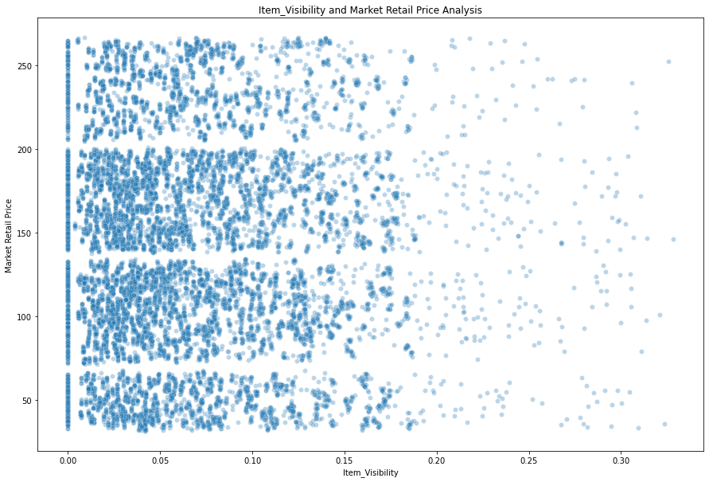

```python
plt.figure(figsize=(15,10))
plt.xlabel("Item_Visibility")
plt.ylabel("Market Retail Price")
plt.title("Item_Visibility and Market Retail Price Analysis")
sns.scatterplot(data.Item_Visibility, data.Item_MRP, alpha=0.3)
```

```
D:\Users\Sushmita Swain\anaconda3\lib\site-packages\seaborn\_decorators.py:43: FutureWarning: Pass the following variables as keyword args: x, y. From version 0.12, the only valid positional argument will be `data`, and passing other arguments without an explicit keyword will result in an error or m…
  FutureWarning
```

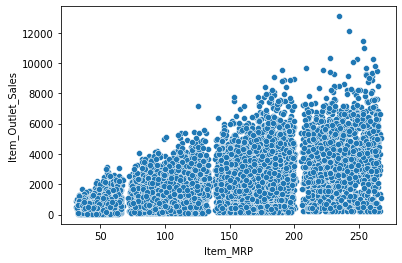

```python
sns.scatterplot(data.Item_MRP, data.Item_Outlet_Sales)
```

```
D:\Users\Sushmita Swain\anaconda3\lib\site-packages\seaborn\_decorators.py:43: FutureWarning: Pass the following variables as keyword args: x, y. From version 0.12, the only valid positional argument will be `data`, and passing other arguments without an explicit keyword will result in an error or m…
  FutureWarning
```

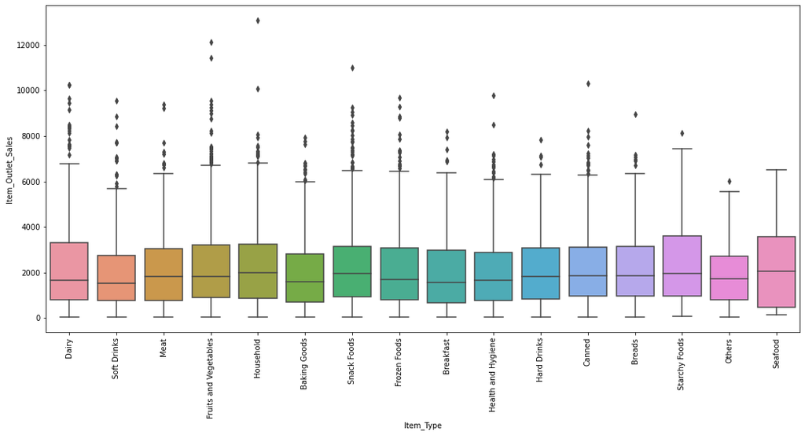

```python
plt.figure(figsize=(18,8))
sns.boxplot(data.Item_Type, data.Item_Outlet_Sales)
plt.xticks(rotation=90)
plt.show()
```

```
D:\Users\Sushmita Swain\anaconda3\lib\site-packages\seaborn\_decorators.py:43: FutureWarning: Pass the following variables as keyword args: x, y. From version 0.12, the only valid positional argument will be `data`, and passing other arguments without an explicit keyword will result in an error or m…
  FutureWarning
```

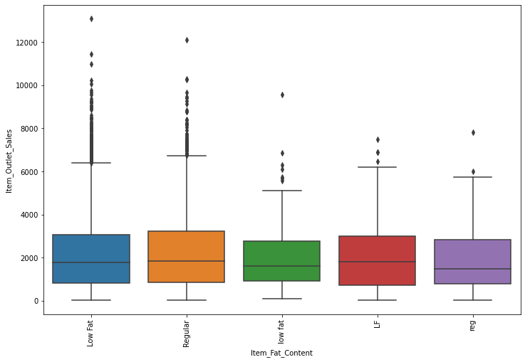

```python
plt.figure(figsize=(12,8))
sns.boxplot(data.Item_Fat_Content, data.Item_Outlet_Sales)
plt.xticks(rotation=90)
plt.show()
```

```
D:\Users\Sushmita Swain\anaconda3\lib\site-packages\seaborn\_decorators.py:43: FutureWarning: Pass the following variables as keyword args: x, y. From version 0.12, the only valid positional argument will be `data`, and passing other arguments without an explicit keyword will result in an error or m…
  FutureWarning
```

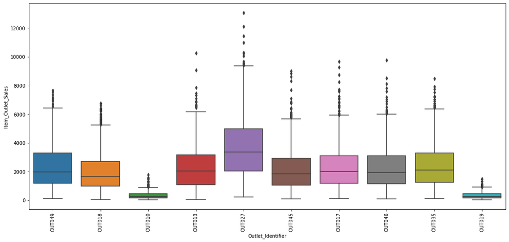

```python
plt.figure(figsize=(18,8))
sns.boxplot(data.Outlet_Identifier, data.Item_Outlet_Sales)
plt.xticks(rotation=90)
plt.show()
```

```
D:\Users\Sushmita Swain\anaconda3\lib\site-packages\seaborn\_decorators.py:43: FutureWarning: Pass the following variables as keyword args: x, y. From version 0.12, the only valid positional argument will be `data`, and passing other arguments without an explicit keyword will result in an error or m…
  FutureWarning
```

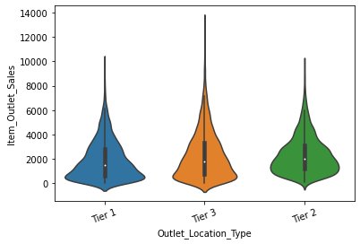

```python
sns.violinplot(data.Outlet_Location_Type, data.Item_Outlet_Sales)
plt.xticks(rotation=20)
plt.show()
```

```
D:\Users\Sushmita Swain\anaconda3\lib\site-packages\seaborn\_decorators.py:43: FutureWarning: Pass the following variables as keyword args: x, y. From version 0.12, the only valid positional argument will be `data`, and passing other arguments without an explicit keyword will result in an error or m…
  FutureWarning
```

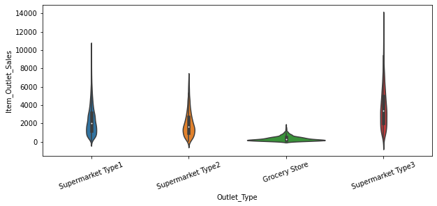

```python
plt.figure(figsize=(10,4))
sns.violinplot(data.Outlet_Type, data.Item_Outlet_Sales)
plt.xticks(rotation=20)
plt.show()
```

```
D:\Users\Sushmita Swain\anaconda3\lib\site-packages\seaborn\distributions.py:305: UserWarning: Dataset has 0 variance; skipping density estimate.
  warnings.warn(msg, UserWarning)
```

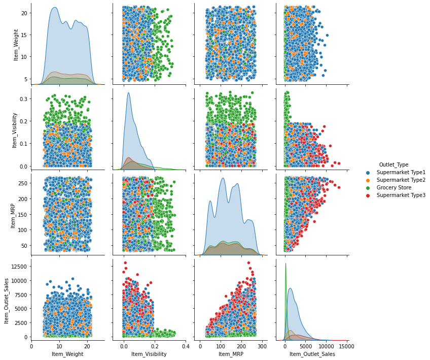

```python
sns.pairplot(data.drop(columns='Outlet_Establishment_Year'), hue='Outlet_Type')
```

##### Finding Missing Values

```python
#We can see that we have some data missing

round(100*(data.isna().sum())/len(data), 2)
```

```
Item_Identifier              0.00000
Item_Weight                 17.17000
Item_Fat_Content             0.00000
Item_Visibility              0.00000
Item_Type                    0.00000
Item_MRP                     0.00000
Outlet_Identifier            0.00000
Outlet_Establishment_Year    0.00000
Outlet_Size                 28.27000
Outlet_Location_Type         0.00000
Outlet_Type                  0.00000
Item_Outlet_Sales           40.00000
dtype: float64
```

```python
#Looking for any '0' Values
data[data==0].sum()
```

```
Item_Identifier             0.00000
Item_Weight                 0.00000
Item_Fat_Content            0.00000
Item_Visibility             0.00000
Item_Type                   0.00000
Item_MRP                    0.00000
Outlet_Identifier           0.00000
Outlet_Establishment_Year   0.00000
Outlet_Size                 0.00000
Outlet_Location_Type        0.00000
Outlet_Type                 0.00000
Item_Outlet_Sales           0.00000
dtype: float64
```

Filling the mssing data in Item_weight with mean

Because every item should have some weigh

```python
data['Item_Weight'].fillna(data['Item_Weight'].mean(), inplace=True)
```

```python
data.head()
```

|  | Item_Identifier | Item_Weight | Item_Fat_Content | Item_Visibility | Item_Type | Item_MRP | Outlet_Identifier | Outlet_Establishment_Year | Outlet_Size | Outlet_Location_Type | Outlet_Type | Item_Outlet_Sales |
| --- | --- | --- | --- | --- | --- | --- | --- | --- | --- | --- | --- | --- |
| 0 | FDA15 | 9.30000 | Low Fat | 0.01605 | Dairy | 249.80920 | OUT049 | 1999 | Medium | Tier 1 | Supermarket Type1 | 3735.13800 |
| 1 | DRC01 | 5.92000 | Regular | 0.01928 | Soft Drinks | 48.26920 | OUT018 | 2009 | Medium | Tier 3 | Supermarket Type2 | 443.42280 |
| 2 | FDN15 | 17.50000 | Low Fat | 0.01676 | Meat | 141.61800 | OUT049 | 1999 | Medium | Tier 1 | Supermarket Type1 | 2097.27000 |
| 3 | FDX07 | 19.20000 | Regular | 0.00000 | Fruits and Vegetables | 182.09500 | OUT010 | 1998 | NaN | Tier 3 | Grocery Store | 732.38000 |
| 4 | NCD19 | 8.93000 | Low Fat | 0.00000 | Household | 53.86140 | OUT013 | 1987 | High | Tier 3 | Supermarket Type1 | 994.70520 |

#### Correlation

```python
data.corr()
```

|  | Item_Weight | Item_Visibility | Item_MRP | Outlet_Establishment_Year | Item_Outlet_Sales |
| --- | --- | --- | --- | --- | --- |
| Item_Weight | 1.00000 | -0.01364 | 0.03300 | 0.00046 | 0.01108 |
| Item_Visibility | -0.01364 | 1.00000 | -0.00635 | -0.08368 | -0.12862 |
| Item_MRP | 0.03300 | -0.00635 | 1.00000 | 0.00014 | 0.56757 |
| Outlet_Establishment_Year | 0.00046 | -0.08368 | 0.00014 | 1.00000 | -0.04913 |
| Item_Outlet_Sales | 0.01108 | -0.12862 | 0.56757 | -0.04913 | 1.00000 |

```python
#Checking the Correlation between data with respect to target

data.corr()['Item_Outlet_Sales']
```

```
Item_Weight                  0.01108
Item_Visibility             -0.12862
Item_MRP                     0.56757
Outlet_Establishment_Year   -0.04913
Item_Outlet_Sales            1.00000
Name: Item_Outlet_Sales, dtype: float64
```

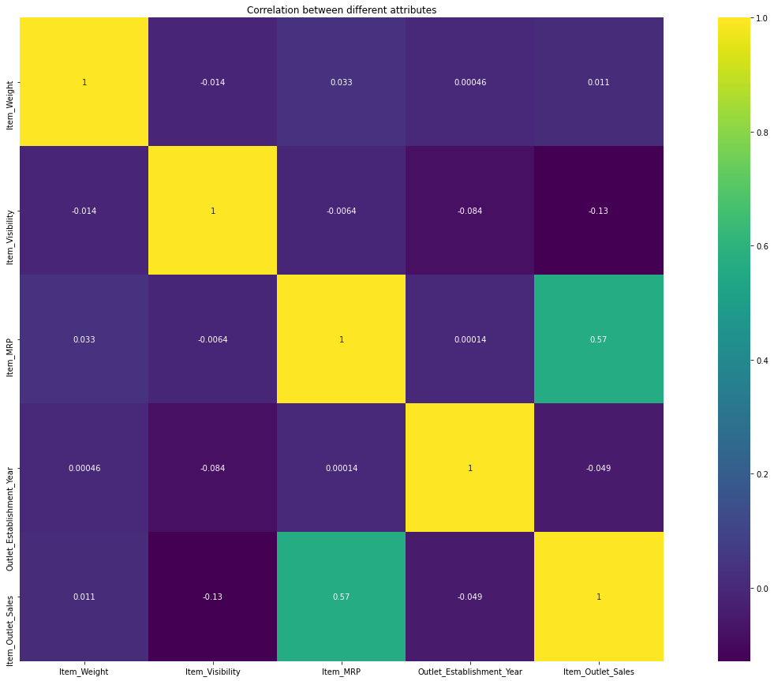

```python
plt.figure(figsize=(25,15))
sns.heatmap(data.corr(), vmax=1, square=True, annot=True, cmap='viridis')
plt.title("Correlation between different attributes")
```

```python
data.head()
```

|  | Item_Identifier | Item_Weight | Item_Fat_Content | Item_Visibility | Item_Type | Item_MRP | Outlet_Identifier | Outlet_Establishment_Year | Outlet_Size | Outlet_Location_Type | Outlet_Type | Item_Outlet_Sales |
| --- | --- | --- | --- | --- | --- | --- | --- | --- | --- | --- | --- | --- |
| 0 | FDA15 | 9.30000 | Low Fat | 0.01605 | Dairy | 249.80920 | OUT049 | 1999 | Medium | Tier 1 | Supermarket Type1 | 3735.13800 |
| 1 | DRC01 | 5.92000 | Regular | 0.01928 | Soft Drinks | 48.26920 | OUT018 | 2009 | Medium | Tier 3 | Supermarket Type2 | 443.42280 |
| 2 | FDN15 | 17.50000 | Low Fat | 0.01676 | Meat | 141.61800 | OUT049 | 1999 | Medium | Tier 1 | Supermarket Type1 | 2097.27000 |
| 3 | FDX07 | 19.20000 | Regular | 0.00000 | Fruits and Vegetables | 182.09500 | OUT010 | 1998 | NaN | Tier 3 | Grocery Store | 732.38000 |
| 4 | NCD19 | 8.93000 | Low Fat | 0.00000 | Household | 53.86140 | OUT013 | 1987 | High | Tier 3 | Supermarket Type1 | 994.70520 |

### Transform Data

```python
item_visiblity_avg = data.pivot_table( index = 'Item_Identifier', values = 'Item_Visibility')
item_visiblity_avg.head()
```

| Item_Identifier | Item_Visibility |
| --- | --- |
| DRA12 | 0.03494 |
| DRA24 | 0.04565 |
| DRA59 | 0.13338 |
| DRB01 | 0.07974 |
| DRB13 | 0.00680 |

```python
data['Item_visiblity_avg'] = data.apply(lambda x: x['Item_Visibility']/item_visiblity_avg['Item_Visibility'][item_visiblity_avg.index==x['Item_Identifier']][0], axis=1).astype(float)
```

```python
data.head()
```

|  | Item_Identifier | Item_Weight | Item_Fat_Content | Item_Visibility | Item_Type | Item_MRP | Outlet_Identifier | Outlet_Establishment_Year | Outlet_Size | Outlet_Location_Type | Outlet_Type | Item_Outlet_Sales | Item_visiblity_avg |
| --- | --- | --- | --- | --- | --- | --- | --- | --- | --- | --- | --- | --- | --- |
| 0 | FDA15 | 9.30000 | Low Fat | 0.01605 | Dairy | 249.80920 | OUT049 | 1999 | Medium | Tier 1 | Supermarket Type1 | 3735.13800 | 0.93108 |
| 1 | DRC01 | 5.92000 | Regular | 0.01928 | Soft Drinks | 48.26920 | OUT018 | 2009 | Medium | Tier 3 | Supermarket Type2 | 443.42280 | 0.93342 |
| 2 | FDN15 | 17.50000 | Low Fat | 0.01676 | Meat | 141.61800 | OUT049 | 1999 | Medium | Tier 1 | Supermarket Type1 | 2097.27000 | 0.96007 |
| 3 | FDX07 | 19.20000 | Regular | 0.00000 | Fruits and Vegetables | 182.09500 | OUT010 | 1998 | NaN | Tier 3 | Grocery Store | 732.38000 | 0.00000 |
| 4 | NCD19 | 8.93000 | Low Fat | 0.00000 | Household | 53.86140 | OUT013 | 1987 | High | Tier 3 | Supermarket Type1 | 994.70520 | 0.00000 |

```python
data['Item_Visibility'], _ = stats.boxcox(data['Item_Visibility'] + 1)
```

```
D:\Users\Sushmita Swain\anaconda3\lib\site-packages\seaborn\distributions.py:2551: FutureWarning: `distplot` is a deprecated function and will be removed in a future version. Please adapt your code to use either `displot` (a figure-level function with similar flexibility) or `histplot` (an axes-leve…
  warnings.warn(msg, FutureWarning)
```

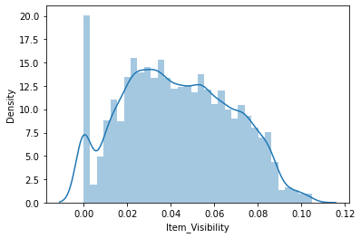

```python
sns.distplot(data['Item_Visibility'])
```

```python
'''

We saw that in Item_identifier 1st 2 character's are common and other characters describes about the product

So we can extract those characters to simplify our dataset

'''

data['Item_Type_Combined'] = data['Item_Identifier'].apply(lambda x: x[0:2])
data['Item_Type_Combined'].value_counts()
```

```
FD    10201
NC     2686
DR     1317
Name: Item_Type_Combined, dtype: int64
```

```python
data.head()
```

|  | Item_Identifier | Item_Weight | Item_Fat_Content | Item_Visibility | Item_Type | Item_MRP | Outlet_Identifier | Outlet_Establishment_Year | Outlet_Size | Outlet_Location_Type | Outlet_Type | Item_Outlet_Sales | Item_visiblity_avg | Item_Type_Combined |
| --- | --- | --- | --- | --- | --- | --- | --- | --- | --- | --- | --- | --- | --- | --- |
| 0 | FDA15 | 9.30000 | Low Fat | 0.01486 | Dairy | 249.80920 | OUT049 | 1999 | Medium | Tier 1 | Supermarket Type1 | 3735.13800 | 0.93108 | FD |
| 1 | DRC01 | 5.92000 | Regular | 0.01759 | Soft Drinks | 48.26920 | OUT018 | 2009 | Medium | Tier 3 | Supermarket Type2 | 443.42280 | 0.93342 | DR |
| 2 | FDN15 | 17.50000 | Low Fat | 0.01547 | Meat | 141.61800 | OUT049 | 1999 | Medium | Tier 1 | Supermarket Type1 | 2097.27000 | 0.96007 | FD |
| 3 | FDX07 | 19.20000 | Regular | 0.00000 | Fruits and Vegetables | 182.09500 | OUT010 | 1998 | NaN | Tier 3 | Grocery Store | 732.38000 | 0.00000 | FD |
| 4 | NCD19 | 8.93000 | Low Fat | 0.00000 | Household | 53.86140 | OUT013 | 1987 | High | Tier 3 | Supermarket Type1 | 994.70520 | 0.00000 | NC |

Rearranging the Columns To get the better view of data

```python
columns = ['Item_Identifier', 'Item_Type_Combined','Item_Type', 'Item_Fat_Content', 'Item_Weight', 'Item_Visibility',
        'Item_visiblity_avg', 'Item_MRP', 'Outlet_Identifier',
       'Outlet_Establishment_Year', 'Outlet_Size', 'Outlet_Location_Type',
       'Outlet_Type', 'Item_Outlet_Sales']
data = data[columns]
data.head()
```

|  | Item_Identifier | Item_Type_Combined | Item_Type | Item_Fat_Content | Item_Weight | Item_Visibility | Item_visiblity_avg | Item_MRP | Outlet_Identifier | Outlet_Establishment_Year | Outlet_Size | Outlet_Location_Type | Outlet_Type | Item_Outlet_Sales |
| --- | --- | --- | --- | --- | --- | --- | --- | --- | --- | --- | --- | --- | --- | --- |
| 0 | FDA15 | FD | Dairy | Low Fat | 9.30000 | 0.01486 | 0.93108 | 249.80920 | OUT049 | 1999 | Medium | Tier 1 | Supermarket Type1 | 3735.13800 |
| 1 | DRC01 | DR | Soft Drinks | Regular | 5.92000 | 0.01759 | 0.93342 | 48.26920 | OUT018 | 2009 | Medium | Tier 3 | Supermarket Type2 | 443.42280 |
| 2 | FDN15 | FD | Meat | Low Fat | 17.50000 | 0.01547 | 0.96007 | 141.61800 | OUT049 | 1999 | Medium | Tier 1 | Supermarket Type1 | 2097.27000 |
| 3 | FDX07 | FD | Fruits and Vegetables | Regular | 19.20000 | 0.00000 | 0.00000 | 182.09500 | OUT010 | 1998 | NaN | Tier 3 | Grocery Store | 732.38000 |
| 4 | NCD19 | NC | Household | Low Fat | 8.93000 | 0.00000 | 0.00000 | 53.86140 | OUT013 | 1987 | High | Tier 3 | Supermarket Type1 | 994.70520 |

```python
data.pivot_table(values="Item_Outlet_Sales",index=['Item_Type_Combined','Item_Type'],aggfunc='sum')
```

| Item_Type_Combined | Item_Type | Item_Outlet_Sales |
| --- | --- | --- |
| DR | Dairy | 245178.18680 |
|  | Hard Drinks | 457793.42720 |
|  | Soft Drinks | 892897.72200 |
| FD | Baking Goods | 1265525.34220 |
|  | Breads | 553237.18880 |
|  | Breakfast | 232298.95160 |
|  | Canned | 1444151.49260 |
|  | Dairy | 1277415.86440 |
|  | Frozen Foods | 1825734.78860 |
|  | Fruits and Vegetables | 2820059.81680 |
|  | Meat | 917565.61200 |
|  | Seafood | 148868.21940 |
|  | Snack Foods | 2732786.08700 |
|  | Starchy Foods | 351401.25040 |
| NC | Health and Hygiene | 1045200.13780 |
|  | Household | 2055493.71320 |
|  | Others | 325517.60960 |

After we extract 1st 2 characters from Item_identifier we saw that it means to certain item type Now, we can rename them accordingly

```python
data['Item_Type_Combined'] = data['Item_Type_Combined'].map({'FD':'Food','NC':'Non-Consumable','DR':'Drinks'})
data['Item_Type_Combined'].value_counts()
```

```
Food              10201
Non-Consumable     2686
Drinks             1317
Name: Item_Type_Combined, dtype: int64
```

```python
data.Outlet_Size.value_counts()
```

```
Medium    4655
Small     3980
High      1553
Name: Outlet_Size, dtype: int64
```

We saw that Outlet_size have some Nan Values Lets fill them with 'Not_specified' for now. We will work later for it.

```python
data['Outlet_Size'] = data['Outlet_Size'].fillna('Not_specified')
data['Outlet_Size'].value_counts()
```

```
Medium           4655
Not_specified    4016
Small            3980
High             1553
Name: Outlet_Size, dtype: int64
```

```python
data['Item_Fat_Content'].value_counts()
```

```
Low Fat    8485
Regular    4824
LF          522
reg         195
low fat     178
Name: Item_Fat_Content, dtype: int64
```

After looking closely we get that ["LF"," Low Fat"," low fat"] & ["Regular","reg"] are same and just acronyms

```python
data['Item_Fat_Content'] = data['Item_Fat_Content'].replace('LF','Low Fat')

data['Item_Fat_Content'] = data['Item_Fat_Content'].replace('low fat','Low Fat')

data['Item_Fat_Content'] = data['Item_Fat_Content'].replace('reg','Regular')

data['Item_Fat_Content'].value_counts()
```

```
Low Fat    9185
Regular    5019
Name: Item_Fat_Content, dtype: int64
```

```python
data.pivot_table(values="Item_Outlet_Sales",index=['Outlet_Location_Type','Outlet_Size','Outlet_Type'],aggfunc=np.sum)
```

| Outlet_Location_Type | Outlet_Size | Outlet_Type | Item_Outlet_Sales |
| --- | --- | --- | --- |
| Tier 1 | Medium | Supermarket Type1 | 2183969.81020 |
|  | Small | Grocery Store | 179694.09360 |
|  |  | Supermarket Type1 | 2118395.16820 |
| Tier 2 | Not_specified | Supermarket Type1 | 4204190.77100 |
|  | Small | Supermarket Type1 | 2268122.93540 |
| Tier 3 | High | Supermarket Type1 | 2142663.57820 |
|  | Medium | Supermarket Type2 | 1851822.83000 |
|  |  | Supermarket Type3 | 3453926.05140 |
|  | Not_specified | Grocery Store | 188340.17240 |

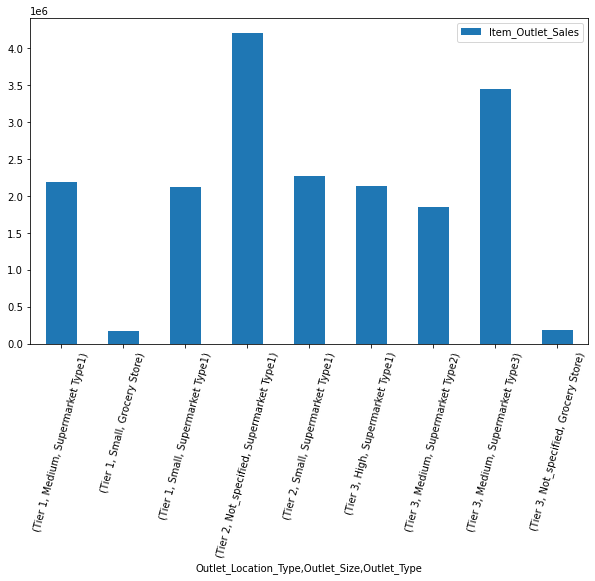

```python
plot_outlet = data.pivot_table(values="Item_Outlet_Sales",index=['Outlet_Location_Type','Outlet_Size','Outlet_Type'],aggfunc=np.sum)
plot_outlet.plot(kind='bar',figsize = (10,6))
plt.xticks(rotation=75)
plt.show()
```

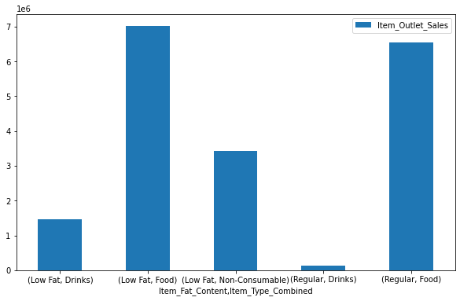

```python
plot_item = data.pivot_table(values="Item_Outlet_Sales",index=['Item_Fat_Content','Item_Type_Combined'],aggfunc='sum')
plot_item.plot(kind='bar',figsize = (10,6))
plt.xticks(rotation=0)
plt.show()
```

```python
data.pivot_table(values="Item_Outlet_Sales",index=['Item_Fat_Content','Item_Type_Combined','Item_Type'],aggfunc='sum')
```

| Item_Fat_Content | Item_Type_Combined | Item_Type | Item_Outlet_Sales |
| --- | --- | --- | --- |
| Low Fat | Drinks | Dairy | 245178.18680 |
|  |  | Hard Drinks | 457793.42720 |
|  |  | Soft Drinks | 761259.07500 |
|  | Food | Baking Goods | 580523.67020 |
|  |  | Breads | 305680.76440 |
|  |  | Breakfast | 99441.89060 |
|  |  | Canned | 753171.60240 |
|  |  | Dairy | 651504.60820 |
|  |  | Frozen Foods | 952890.96260 |
|  |  | Fruits and Vegetables | 1374915.61640 |
|  |  | Meat | 346054.87640 |
|  |  | Seafood | 70588.11600 |
|  |  | Snack Foods | 1669089.35940 |
|  |  | Starchy Foods | 209790.91680 |
|  | Non-Consumable | Health and Hygiene | 1045200.13780 |
|  |  | Household | 2055493.71320 |
|  |  | Others | 325517.60960 |
| Regular | Drinks | Soft Drinks | 131638.64700 |
|  | Food | Baking Goods | 685001.67200 |
|  |  | Breads | 247556.42440 |
|  |  | Breakfast | 132857.06100 |
|  |  | Canned | 690979.89020 |
|  |  | Dairy | 625911.25620 |
|  |  | Frozen Foods | 872843.82600 |
|  |  | Fruits and Vegetables | 1445144.20040 |
|  |  | Meat | 571510.73560 |
|  |  | Seafood | 78280.10340 |
|  |  | Snack Foods | 1063696.72760 |
|  |  | Starchy Foods | 141610.33360 |

From above table we saw that Non_Consumable goods don't fit with Low_Fat. So lets change them accordingly Products looks like Household Items and lets it to Household

```python
data.loc[data['Item_Type_Combined']=="Non-Consumable",'Item_Fat_Content'] = "Household"
```

```python
plot_identifier = data.pivot_table(index="Outlet_Identifier", values="Item_Outlet_Sales", aggfunc=np.sum)
plot_identifier
```

| Outlet_Identifier | Item_Outlet_Sales |
| --- | --- |
| OUT010 | 188340.17240 |
| OUT013 | 2142663.57820 |
| OUT017 | 2167465.29400 |
| OUT018 | 1851822.83000 |
| OUT019 | 179694.09360 |
| OUT027 | 3453926.05140 |
| OUT035 | 2268122.93540 |
| OUT045 | 2036725.47700 |
| OUT046 | 2118395.16820 |
| OUT049 | 2183969.81020 |

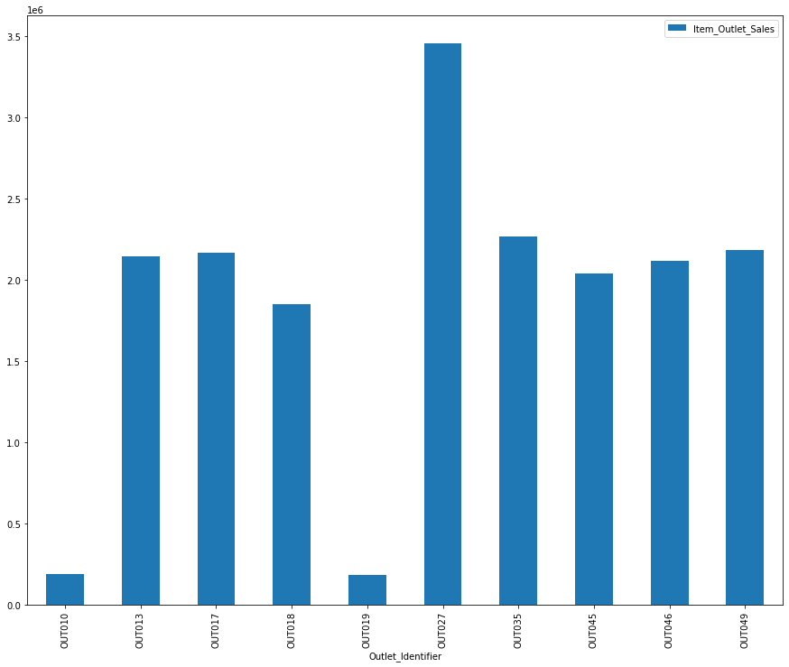

```python
plot_identifier.plot(kind='bar',figsize = (15,12))
plt.show()
```

```python
data.pivot_table(values=['Item_Outlet_Sales'],index=['Outlet_Type','Outlet_Location_Type','Outlet_Size','Outlet_Identifier'],aggfunc=np.sum)
```

| Outlet_Type | Outlet_Location_Type | Outlet_Size | Outlet_Identifier | Item_Outlet_Sales |
| --- | --- | --- | --- | --- |
| Grocery Store | Tier 1 | Small | OUT019 | 179694.09360 |
|  | Tier 3 | Not_specified | OUT010 | 188340.17240 |
| Supermarket Type1 | Tier 1 | Medium | OUT049 | 2183969.81020 |
|  |  | Small | OUT046 | 2118395.16820 |
|  | Tier 2 | Not_specified | OUT017 | 2167465.29400 |
|  |  |  | OUT045 | 2036725.47700 |
|  |  | Small | OUT035 | 2268122.93540 |
|  | Tier 3 | High | OUT013 | 2142663.57820 |
| Supermarket Type2 | Tier 3 | Medium | OUT018 | 1851822.83000 |
| Supermarket Type3 | Tier 3 | Medium | OUT027 | 3453926.05140 |

```python
data.groupby('Outlet_Identifier')['Item_Outlet_Sales'].sum()
```

```
Outlet_Identifier
OUT010    188340.17240
OUT013   2142663.57820
OUT017   2167465.29400
OUT018   1851822.83000
OUT019    179694.09360
OUT027   3453926.05140
OUT035   2268122.93540
OUT045   2036725.47700
OUT046   2118395.16820
OUT049   2183969.81020
Name: Item_Outlet_Sales, dtype: float64
```

```python
data.Outlet_Identifier.value_counts()
```

```
OUT027    1559
OUT013    1553
OUT049    1550
OUT035    1550
OUT046    1550
OUT045    1548
OUT018    1546
OUT017    1543
OUT010     925
OUT019     880
Name: Outlet_Identifier, dtype: int64
```

When we look Closely Grocery Store have the Lowest Sales

Supermarket Type3 have the Highest sale

After Carefully analyzing Outlet_size and Outlet_Identifier with Sales and Total Number of each Outlet_Identifier I think some Outlet_Identifier are in wrong Outlet_Size lets fix them

```python
data.loc[data['Outlet_Identifier']=="OUT010",'Outlet_Size'] = "Small"

data.loc[data['Outlet_Identifier']=="OUT019",'Outlet_Size'] = "Small"

data.loc[data['Outlet_Identifier']=="OUT027",'Outlet_Size'] = "High"

data.loc[data['Outlet_Identifier']=="OUT017",'Outlet_Size'] = "High"

data.loc[data['Outlet_Identifier']=="OUT045",'Outlet_Size'] = "High"

data.loc[data['Outlet_Identifier']=="OUT035",'Outlet_Size'] = "Medium"

data.loc[data['Outlet_Identifier']=="OUT046",'Outlet_Size'] = "Medium"
```

```python
data.pivot_table(values=['Item_Outlet_Sales'],index=['Outlet_Size','Outlet_Identifier'],aggfunc=np.sum)
```

| Outlet_Size | Outlet_Identifier | Item_Outlet_Sales |
| --- | --- | --- |
| High | OUT013 | 2142663.57820 |
|  | OUT017 | 2167465.29400 |
|  | OUT027 | 3453926.05140 |
|  | OUT045 | 2036725.47700 |
| Medium | OUT018 | 1851822.83000 |
|  | OUT035 | 2268122.93540 |
|  | OUT046 | 2118395.16820 |
|  | OUT049 | 2183969.81020 |
| Small | OUT010 | 188340.17240 |
|  | OUT019 | 179694.09360 |

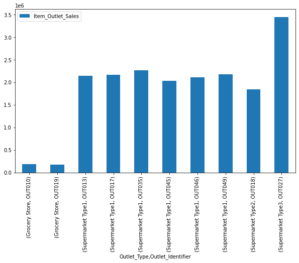

```python
data.pivot_table(values=['Item_Outlet_Sales'],index=['Outlet_Type','Outlet_Identifier'],aggfunc=np.sum).plot(kind='bar',figsize = (10,6))
plt.show()
```

Let's Create New Columns

```python
perishable = ["Breads", "Breakfast", "Dairy", "Snack Foods",
               "Fruits and Vegetables", "Meat", "Seafood", "Starchy Foods"]

non_perishable = ["Baking Goods", "Canned", "Frozen Foods",
                   "Hard Drinks", "Health and Hygiene",
                   "Household", "Soft Drinks"]
```

```python
def filter_data(item):
    if item in perishable:
        return 'perishable'
    elif item in non_perishable:
        return 'non_perishable'
    else:
        return'Not_Known'

data['Item_Type_New'] = data.Item_Type.apply(filter_data)
```

```python
data.Item_Type_New.value_counts()
```

```
non_perishable    7090
perishable        6834
Not_Known          280
Name: Item_Type_New, dtype: int64
```

```
D:\Users\Sushmita Swain\anaconda3\lib\site-packages\seaborn\_decorators.py:43: FutureWarning: Pass the following variables as keyword args: x, y. From version 0.12, the only valid positional argument will be `data`, and passing other arguments without an explicit keyword will result in an error or m…
  FutureWarning
```

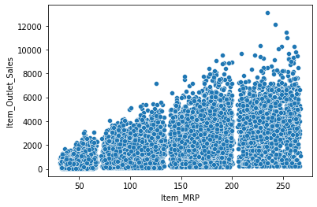

```python
sns.scatterplot(data.Item_MRP, data.Item_Outlet_Sales)
```

```python
data['Item_MRP_cat'] = pd.cut(data.Item_MRP, bins=[31,69,137,203,270], labels=['a','b','c','d'])
```

```python
data.groupby(['Item_Type_Combined', 'Item_Type_New', 'Item_Type'])['Item_Outlet_Sales'].sum()
```

```
Item_Type_Combined  Item_Type_New   Item_Type
Drinks              non_perishable  Hard Drinks              457793.42720
                                    Soft Drinks              892897.72200
                    perishable      Dairy                    245178.18680
Food                non_perishable  Baking Goods            1265525.34220
                                    Canned                  1444151.49260
                                    Frozen Foods            1825734.78860
                    perishable      Breads                   553237.18880
                                    Breakfast                232298.95160
                                    Dairy                   1277415.86440
                                    Fruits and Vegetables   2820059.81680
                                    Meat                     917565.61200
                                    Seafood                  148868.21940
                                    Snack Foods             2732786.08700
                                    Starchy Foods            351401.25040
Non-Consumable      Not_Known       Others                   325517.60960
                    non_perishable  Health and Hygiene      1045200.13780
                                    Household               2055493.71320
Name: Item_Outlet_Sales, dtype: float64
```

```python
data['MRP_per_unit_weight'] = data.Item_MRP/data.Item_Weight
```

```python
data['Outlet_Years'] = 2020 - data['Outlet_Establishment_Year']
```

```python
data.Outlet_Establishment_Year = data.Outlet_Establishment_Year.astype('category')
```

```python
data['Item_Identifier'] = data['Item_Identifier'].apply(lambda x: x[3:5])
```

```python
data.head()
```

|  | Item_Identifier | Item_Type_Combined | Item_Type | Item_Fat_Content | Item_Weight | Item_Visibility | Item_visiblity_avg | Item_MRP | Outlet_Identifier | Outlet_Establishment_Year | Outlet_Size | Outlet_Location_Type | Outlet_Type | Item_Outlet_Sales | Item_Type_New | Item_MRP_cat | MRP_per_unit_weight | Outlet_Years |
| --- | --- | --- | --- | --- | --- | --- | --- | --- | --- | --- | --- | --- | --- | --- | --- | --- | --- | --- |
| 0 | 15 | Food | Dairy | Low Fat | 9.30000 | 0.01486 | 0.93108 | 249.80920 | OUT049 | 1999 | Medium | Tier 1 | Supermarket Type1 | 3735.13800 | perishable | d | 26.86120 | 21 |
| 1 | 01 | Drinks | Soft Drinks | Regular | 5.92000 | 0.01759 | 0.93342 | 48.26920 | OUT018 | 2009 | Medium | Tier 3 | Supermarket Type2 | 443.42280 | non_perishable | a | 8.15358 | 11 |
| 2 | 15 | Food | Meat | Low Fat | 17.50000 | 0.01547 | 0.96007 | 141.61800 | OUT049 | 1999 | Medium | Tier 1 | Supermarket Type1 | 2097.27000 | perishable | c | 8.09246 | 21 |
| 3 | 07 | Food | Fruits and Vegetables | Regular | 19.20000 | 0.00000 | 0.00000 | 182.09500 | OUT010 | 1998 | Small | Tier 3 | Grocery Store | 732.38000 | perishable | c | 9.48411 | 22 |
| 4 | 19 | Non-Consumable | Household | Household | 8.93000 | 0.00000 | 0.00000 | 53.86140 | OUT013 | 1987 | High | Tier 3 | Supermarket Type1 | 994.70520 | non_perishable | a | 6.03151 | 33 |

```python
data.corr()
```

|  | Item_Weight | Item_Visibility | Item_visiblity_avg | Item_MRP | Item_Outlet_Sales | MRP_per_unit_weight | Outlet_Years |
| --- | --- | --- | --- | --- | --- | --- | --- |
| Item_Weight | 1.00000 | -0.01399 | -0.00730 | 0.03300 | 0.01108 | -0.58276 | -0.00046 |
| Item_Visibility | -0.01399 | 1.00000 | 0.47112 | -0.00007 | -0.10059 | -0.00568 | 0.06375 |
| Item_visiblity_avg | -0.00730 | 0.47112 | 1.00000 | -0.00032 | -0.24797 | -0.01374 | 0.16587 |
| Item_MRP | 0.03300 | -0.00007 | -0.00032 | 1.00000 | 0.56757 | 0.70448 | -0.00014 |
| Item_Outlet_Sales | 0.01108 | -0.10059 | -0.24797 | 0.56757 | 1.00000 | 0.39138 | 0.04913 |
| MRP_per_unit_weight | -0.58276 | -0.00568 | -0.01374 | 0.70448 | 0.39138 | 1.00000 | -0.06107 |
| Outlet_Years | -0.00046 | 0.06375 | 0.16587 | -0.00014 | 0.04913 | -0.06107 | 1.00000 |

```python
data['Item_visiblity_avg'] = np.log(data['Item_visiblity_avg'] + 1)
```

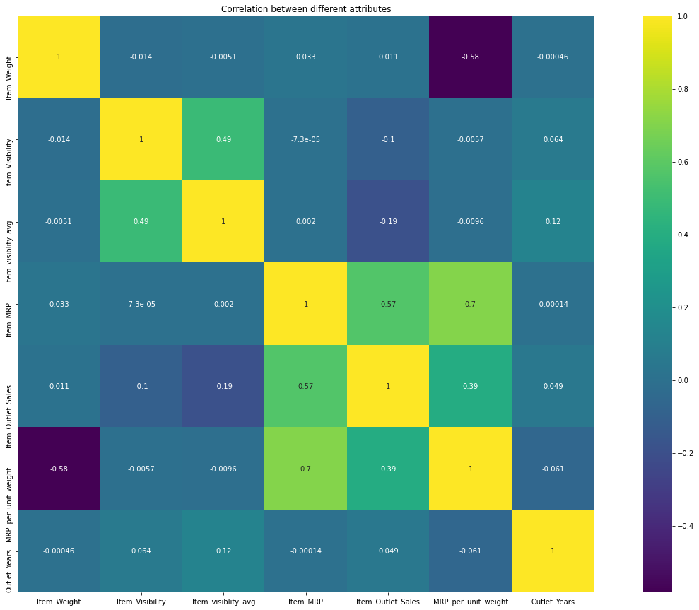

```python
plt.figure(figsize=(25,15))
sns.heatmap(data.corr(), vmax=1, square=True, annot=True, cmap='viridis')
plt.title("Correlation between different attributes")
```

```python
df = data.copy()
```

### Seperating Train and test data

```python
df_train = df.iloc[0:train.shape[0]]
df_test = df.iloc[train.shape[0]:]
```

```python
print(df_train.shape,df_test.shape)
```

```
(8523, 18) (5681, 18)
```

```python
df.info()
```

```
<class 'pandas.core.frame.DataFrame'>
RangeIndex: 14204 entries, 0 to 14203
Data columns (total 18 columns):
 #   Column                     Non-Null Count  Dtype
---  ------                     --------------  -----
 0   Item_Identifier            14204 non-null  object
 1   Item_Type_Combined         14204 non-null  object
 2   Item_Type                  14204 non-null  object
 3   Item_Fat_Content           14204 non-null  object
 4   Item_Weight                14204 non-null  float64
 5   Item_Visibility            14204 non-null  float64
 6   Item_visiblity_avg         14204 non-null  float64
 7   Item_MRP                   14204 non-null  float64
 8   Outlet_Identifier          14204 non-null  object
 9   Outlet_Establishment_Year  14204 non-null  category
 10  Outlet_Size                14204 non-null  object
 11  Outlet_Location_Type       14204 non-null  object
 12  Outlet_Type                14204 non-null  object
 13  Item_Outlet_Sales          8523 non-null   float64
 14  Item_Type_New              14204 non-null  object
 15  Item_MRP_cat               14204 non-null  category
 16  MRP_per_unit_weight        14204 non-null  float64
 17  Outlet_Years               14204 non-null  int64
dtypes: category(2), float64(6), int64(1), object(9)
memory usage: 1.8+ MB
```

```python
df_train.select_dtypes(include='float').columns
```

```
Index(['Item_Weight', 'Item_Visibility', 'Item_visiblity_avg', 'Item_MRP',
       'Item_Outlet_Sales', 'MRP_per_unit_weight'],
      dtype='object')
```

```python
df_train = pd.get_dummies(df_train)
```

```python
df_train.corr()['Item_Outlet_Sales']
```

```
Item_Weight                          0.01108
Item_Visibility                     -0.10059
Item_visiblity_avg                  -0.18884
Item_MRP                             0.56757
Item_Outlet_Sales                    1.00000
MRP_per_unit_weight                  0.39138
Outlet_Years                         0.04913
Item_Identifier_01                  -0.00564
Item_Identifier_02                   0.00736
Item_Identifier_03                   0.00040
Item_Identifier_04                  -0.02477
Item_Identifier_05                   0.00644
Item_Identifier_06                   0.00443
Item_Identifier_07                  -0.01714
Item_Identifier_08                  -0.00829
Item_Identifier_09                  -0.00299
Item_Identifier_10                  -0.03370
Item_Identifier_11                   0.02217
Item_Identifier_12                  -0.01436
Item_Identifier_13                  -0.02104
Item_Identifier_14                  -0.02391
Item_Identifier_15                   0.00805
Item_Identifier_16                   0.01041
Item_Identifier_17                   0.00933
Item_Identifier_18                   0.04189
Item_Identifier_19                   0.00570
Item_Identifier_20                   0.01693
Item_Identifier_21                   0.01849
Item_Identifier_22                  -0.00485
Item_Identifier_23                   0.00532
Item_Identifier_24                  -0.01955
Item_Identifier_25                  -0.00087
Item_Identifier_26                   0.02253
Item_Identifier_27                  -0.02458
Item_Identifier_28                  -0.01434
Item_Identifier_29                  -0.02784
Item_Identifier_30                  -0.02201
Item_Identifier_31                  -0.00637
Item_Identifier_32                  -0.02580
Item_Identifier_33                   0.01843
```

[output cut: 71 more lines]

```
Outlet_Location_Type_Tier 1         -0.11129
Outlet_Location_Type_Tier 2          0.05826
Outlet_Location_Type_Tier 3          0.04638
Outlet_Type_Grocery Store           -0.41173
Outlet_Type_Supermarket Type1        0.10877
Outlet_Type_Supermarket Type2       -0.03806
Outlet_Type_Supermarket Type3        0.31119
Item_Type_New_Not_Known             -0.02127
Item_Type_New_non_perishable        -0.03661
Item_Type_New_perishable             0.04257
Item_MRP_cat_a                      -0.36587
Item_MRP_cat_b                      -0.22885
Item_MRP_cat_c                       0.19443
Item_MRP_cat_d                       0.39442
Name: Item_Outlet_Sales, dtype: float64
```

```python
df_train.head()
```

|  | Item_Weight | Item_Visibility | Item_visiblity_avg | Item_MRP | Item_Outlet_Sales | MRP_per_unit_weight | Outlet_Years | Item_Identifier_01 | Item_Identifier_02 | Item_Identifier_03 | Item_Identifier_04 | Item_Identifier_05 | Item_Identifier_06 | Item_Identifier_07 | Item_Identifier_08 | Item_Identifier_09 | Item_Identifier_10 | Item_Identifier_11 | Item_Identifier_12 | Item_Identifier_13 | Item_Identifier_14 | Item_Identifier_15 | Item_Identifier_16 | Item_Identifier_17 | Item_Identifier_18 | Item_Identifier_19 | Item_Identifier_20 | Item_Identifier_21 | Item_Identifier_22 | … |
| --- | --- | --- | --- | --- | --- | --- | --- | --- | --- | --- | --- | --- | --- | --- | --- | --- | --- | --- | --- | --- | --- | --- | --- | --- | --- | --- | --- | --- | --- | --- |
| 0 | 9.30000 | 0.01486 | 0.65808 | 249.80920 | 3735.13800 | 26.86120 | 21 | 0 | 0 | 0 | 0 | 0 | 0 | 0 | 0 | 0 | 0 | 0 | 0 | 0 | 0 | 1 | 0 | 0 | 0 | 0 | 0 | 0 | 0 | … |
| 1 | 5.92000 | 0.01759 | 0.65929 | 48.26920 | 443.42280 | 8.15358 | 11 | 1 | 0 | 0 | 0 | 0 | 0 | 0 | 0 | 0 | 0 | 0 | 0 | 0 | 0 | 0 | 0 | 0 | 0 | 0 | 0 | 0 | 0 | … |
| 2 | 17.50000 | 0.01547 | 0.67298 | 141.61800 | 2097.27000 | 8.09246 | 21 | 0 | 0 | 0 | 0 | 0 | 0 | 0 | 0 | 0 | 0 | 0 | 0 | 0 | 0 | 1 | 0 | 0 | 0 | 0 | 0 | 0 | 0 | … |
| 3 | 19.20000 | 0.00000 | 0.00000 | 182.09500 | 732.38000 | 9.48411 | 22 | 0 | 0 | 0 | 0 | 0 | 0 | 1 | 0 | 0 | 0 | 0 | 0 | 0 | 0 | 0 | 0 | 0 | 0 | 0 | 0 | 0 | 0 | … |
| 4 | 8.93000 | 0.00000 | 0.00000 | 53.86140 | 994.70520 | 6.03151 | 33 | 0 | 0 | 0 | 0 | 0 | 0 | 0 | 0 | 0 | 0 | 0 | 0 | 0 | 0 | 0 | 0 | 0 | 0 | 1 | 0 | 0 | 0 | … |

```python
df_train.shape
```

```
(8523, 125)
```

```python
df_train.info()
```

```
<class 'pandas.core.frame.DataFrame'>
RangeIndex: 8523 entries, 0 to 8522
Columns: 125 entries, Item_Weight to Item_MRP_cat_d
dtypes: float64(6), int64(1), uint8(118)
memory usage: 1.4 MB
```

```python
df_x = df_train.drop(['Item_Outlet_Sales'], axis=1)
df_y = df_train['Item_Outlet_Sales']
```

```python
x_train, x_test, y_train, y_test=train_test_split(df_x,df_y, train_size=0.8, random_state=10)
```

### Machine Learning Model

```python
lr = LinearRegression()

rfc = ensemble.RandomForestRegressor(n_estimators=400, bootstrap=True, min_samples_leaf=100, min_samples_split=8, max_depth=6)
ada = ensemble.AdaBoostRegressor(n_estimators=1000, learning_rate=0.01)
gbr = ensemble.GradientBoostingRegressor(learning_rate=0.01, n_estimators=1000, max_depth=5, min_samples_split=8, min_samples_leaf=100)
xgb = XGBRFRegressor(n_jobs=-1, n_estimators=1000, max_depth=5)
cat = CatBoostRegressor(verbose=0)
dtr = DecisionTreeRegressor(max_depth=15, min_samples_leaf=100)
lgbr = LGBMRegressor(n_estimators = 440, learning_rate=0.01, max_depth=12, objective='tweedie', num_leaves=15, num_threads = 4)

knn = KNeighborsRegressor()

mlp = MLPRegressor()

svr = SVR(kernel='linear', C=10, gamma='scale')
```

```python
accuracy = {}
rmse = {}
explained_variance = {}
max_error = {}
MAE = {}

def train_model(model, model_name):
    print(model_name)
    model.fit(x_train,y_train)
    pred = model.predict(x_test)

    acc = metrics.r2_score(y_test, pred)*100
    accuracy[model_name] = acc
    print('R2_Score',acc)

    met = np.sqrt(metrics.mean_squared_error(y_test, pred))
    print('RMSE : ', met)
    rmse[model_name] = met

    var = (metrics.explained_variance_score(y_test, pred))
    print('Explained_Variance : ', var)
    explained_variance[model_name] = var

    error = (metrics.max_error(y_test, pred))
    print('Max_Error : ', error)
    max_error[model_name] = error

    err = metrics.mean_absolute_error(y_test, pred)
    print("Mean Absolute Error", err)
    MAE[model_name] = err
```

```python
train_model(cat, "Cat Boost")
```

```
Cat Boost
R2_Score 57.87526992627774
RMSE :  1118.2287143590686
Explained_Variance :  0.5787723206748085
Max_Error :  6568.790685323858
Mean Absolute Error 782.5228859917165
```

```python
train_model(svr, "Support Vector Machine")
```

```
Support Vector Machine
R2_Score 55.75887643879855
RMSE :  1145.975013516125
Explained_Variance :  0.5636531260413922
Max_Error :  8492.644913695738
Mean Absolute Error 824.4232521876091
```

```python
train_model(lr, "Linear Regression")
```

```
Linear Regression
R2_Score 57.317248441325894
RMSE :  1125.6108711339407
Explained_Variance :  0.5732015810104601
Max_Error :  7884.824175
Mean Absolute Error 832.7891037573314
```

```python
train_model(rfc, "Random Forest")
```

```
Random Forest
R2_Score 60.37614946263674
RMSE :  1084.527110953086
Explained_Variance :  0.6040415648446562
Max_Error :  7462.732115618053
Mean Absolute Error 764.4698813251458
```

```python
train_model(xgb, "Xtreme Gradient Random Forest")
```

```
Xtreme Gradient Random Forest
R2_Score 60.37530518418366
RMSE :  1084.5386650799783
Explained_Variance :  0.6039716189804316
Max_Error :  7458.55806171875
Mean Absolute Error 761.2249755264345
```

```python
train_model(ada, "Ada Boost")
```

```
Ada Boost
R2_Score 57.31761418256176
RMSE :  1125.6060485395906
Explained_Variance :  0.5886503437033809
Max_Error :  7448.682094080998
Mean Absolute Error 841.8206896166469
```

```python
train_model(gbr, "Gradient Boost")
```

```
Gradient Boost
R2_Score 60.91740492869591
RMSE :  1077.0944077830097
Explained_Variance :  0.609363152331089
Max_Error :  7589.416418705169
Mean Absolute Error 755.9414114993924
```

```python
train_model(dtr, "Decision Tree")
```

```
Decision Tree
R2_Score 59.4351862458014
RMSE :  1097.3289012601624
Explained_Variance :  0.5946217612618688
Max_Error :  7245.782507142858
Mean Absolute Error 770.462864109759
```

```python
train_model(mlp, "Multi-layer Perceptron")
```

```
Multi-layer Perceptron
R2_Score 59.097934502050165
RMSE :  1101.8809999692228
Explained_Variance :  0.5910204709666631
Max_Error :  7770.026819002084
Mean Absolute Error 806.3779168375521
```

```
D:\Users\Sushmita Swain\anaconda3\lib\site-packages\sklearn\neural_network\_multilayer_perceptron.py:585: ConvergenceWarning: Stochastic Optimizer: Maximum iterations (200) reached and the optimization hasn't converged yet.
  % self.max_iter, ConvergenceWarning)
```

```python
train_model(knn, "K Nearest Neighbors")
```

```
K Nearest Neighbors
R2_Score 47.59181630222017
RMSE :  1247.2733093802758
Explained_Variance :  0.4772726552911165
Max_Error :  7690.655799999999
Mean Absolute Error 888.3640925982404
```

```python
train_model(lgbr, 'Light Gradient Boost')
```

```
Light Gradient Boost
[LightGBM] [Warning] num_threads is set=4, n_jobs=-1 will be ignored. Current value: num_threads=4
R2_Score 60.84238253544323
RMSE :  1078.1276996953104
Explained_Variance :  0.6084302950054792
Max_Error :  7756.068527182407
Mean Absolute Error 755.2918738288357
```

```python
# from ngboost import NGBRegressor
# ngb = NGBRegressor(minibatch_frac=0.5, col_sample=0.5, Base=dtr)
# train_model(ngb, "Natural Grading Boost")
```